# Assignment 8

Feiyu Zheng (fz114)

2022/4/8

# Problem 1

## For the gapminder data, perform the following operations, using the `tidy::nest()` function and and data frames with list-columns:

## 1. Fit a separate linear model of `log10(gdpPercap)` on year for each country.

### Import *gapminder* package

```r
library(gapminder)
```

### Generate the nested data by country and continent.

```r
gap_nested <- gapminder %>%
  group_by(country, continent) %>%
  nest()
gap_nested
```

```
## # A tibble: 142 x 3
## # Groups:   country, continent [142]
##    country     continent data
##    <fct>       <fct>     <list>
##  1 Afghanistan Asia      <tibble [12 x 4]>
##  2 Albania     Europe    <tibble [12 x 4]>
##  3 Algeria     Africa    <tibble [12 x 4]>
##  4 Angola      Africa    <tibble [12 x 4]>
##  5 Argentina   Americas  <tibble [12 x 4]>
##  6 Australia   Oceania   <tibble [12 x 4]>
##  7 Austria     Europe    <tibble [12 x 4]>
##  8 Bahrain     Asia      <tibble [12 x 4]>
##  9 Bangladesh  Asia      <tibble [12 x 4]>
## 10 Belgium     Europe    <tibble [12 x 4]>
## # ... with 132 more rows
```

### Fit a linear model on each country

```r
gap_nested_lm <- gap_nested %>%
  mutate(model = map(data, ~lm(log10(gdpPercap) ~ year, data = .)))
gap_nested_lm
```

```
## # A tibble: 142 x 4
## # Groups:   country, continent [142]
##    country     continent data              model
##    <fct>       <fct>     <list>            <list>
##  1 Afghanistan Asia      <tibble [12 x 4]> <lm>
##  2 Albania     Europe    <tibble [12 x 4]> <lm>
##  3 Algeria     Africa    <tibble [12 x 4]> <lm>
##  4 Angola      Africa    <tibble [12 x 4]> <lm>
##  5 Argentina   Americas  <tibble [12 x 4]> <lm>
##  6 Australia   Oceania   <tibble [12 x 4]> <lm>
##  7 Austria     Europe    <tibble [12 x 4]> <lm>
##  8 Bahrain     Asia      <tibble [12 x 4]> <lm>
##  9 Bangladesh  Asia      <tibble [12 x 4]> <lm>
## 10 Belgium     Europe    <tibble [12 x 4]> <lm>
## # ... with 132 more rows
```

## 2. Plot residuals against time, showing separate lines for each country in the same plot. Also, do this separately for each continent.

### Compute and add the residuals to the tibble

```r
gap_nested_lm_resid <- gap_nested_lm %>%
  mutate(resid = map2(data, model, add_residuals)) %>%
  unnest(resid)
gap_nested_lm_resid
```

```
## # A tibble: 1,704 x 9
## # Groups:   country, continent [142]
##    country     continent data     model   year lifeExp    pop gdpPercap    resid
##    <fct>       <fct>     <list>   <list> <int>   <dbl>  <int>     <dbl>    <dbl>
##  1 Afghanistan Asia      <tibble> <lm>    1952    28.8 8.43e6      779. -0.0202
##  2 Afghanistan Asia      <tibble> <lm>    1957    30.3 9.24e6      821.  0.00433
##  3 Afghanistan Asia      <tibble> <lm>    1962    32.0 1.03e7      853.  0.0231
##  4 Afghanistan Asia      <tibble> <lm>    1967    34.0 1.15e7      836.  0.0164
##  5 Afghanistan Asia      <tibble> <lm>    1972    36.1 1.31e7      740. -0.0347
##  6 Afghanistan Asia      <tibble> <lm>    1977    38.4 1.49e7      786. -0.00641
##  7 Afghanistan Asia      <tibble> <lm>    1982    39.9 1.29e7      978.  0.0905
##  8 Afghanistan Asia      <tibble> <lm>    1987    40.8 1.39e7      852.  0.0328
##  9 Afghanistan Asia      <tibble> <lm>    1992    41.7 1.63e7      649. -0.0834
## 10 Afghanistan Asia      <tibble> <lm>    1997    41.8 2.22e7      635. -0.0909
## # ... with 1,694 more rows
```

### Residuals graph for each country

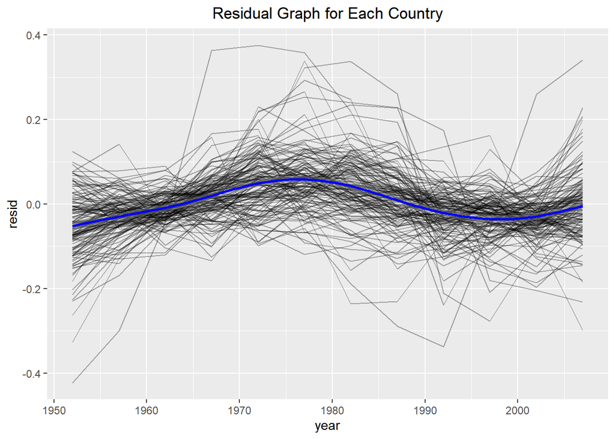

```r
gap_nested_lm_resid %>%
  ggplot(aes(year, resid)) +
  geom_line(alpha = 1/3, aes(group = country)) +
  geom_smooth(color = "blue") +
  labs(
    title = "Residual Graph for Each Country"
  ) +
  theme(plot.title = element_text(hjust = 0.5))
```

### Residuals graph for each continent

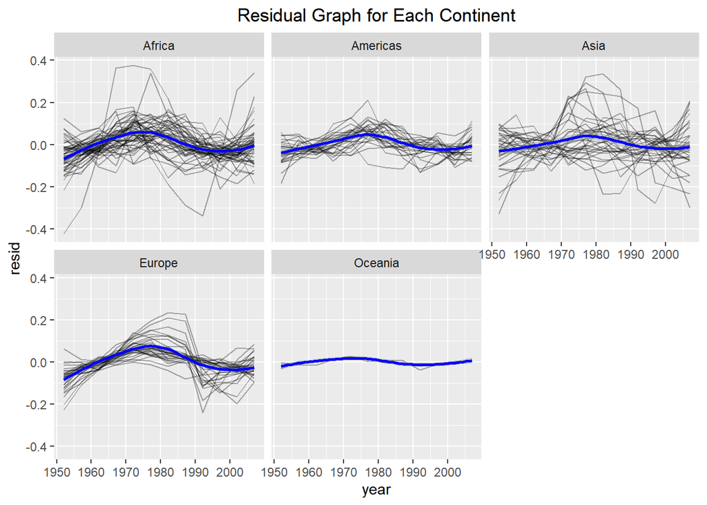

```r
gap_nested_lm_resid %>%
  ggplot(aes(year, resid)) +
  geom_line(alpha = 1/3, aes(group = country)) +
  geom_smooth(color = "blue") +
  facet_wrap(~continent) +
  labs(
    title = "Residual Graph for Each Continent"
  ) +
  theme(plot.title = element_text(hjust = 0.5))
```

## 3. Create a continent-wise Beeswarmplot for

### (i) value of the estimated slope coefficient

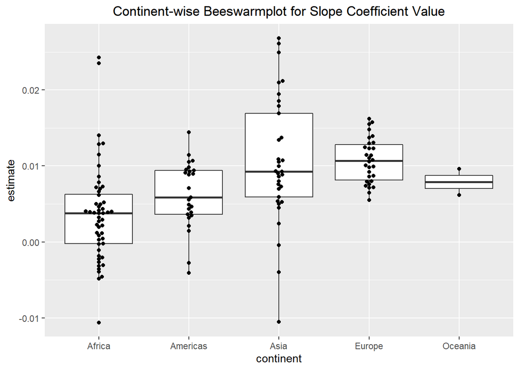

```r
gap_nested_lm_tidy <- gap_nested_lm %>%
  mutate(tidy = map(model, tidy))

gap_nested_lm_tidy %>%
  mutate(tidy = map(tidy, ~filter(., term == "year"))) %>%
  unnest(tidy) %>%
  ggplot(aes(continent, estimate)) +
  geom_boxplot() +
  geom_beeswarm() +
  labs(
    title = "Continent-wise Beeswarmplot for Slope Coefficient Value"
  ) +
  theme(plot.title = element_text(hjust = 0.5))
```

### (ii) value of the t-statistic (ratio of estimate and standard error). [Hint: you may need to revisit the materials on broom package]. Interpret the plots.

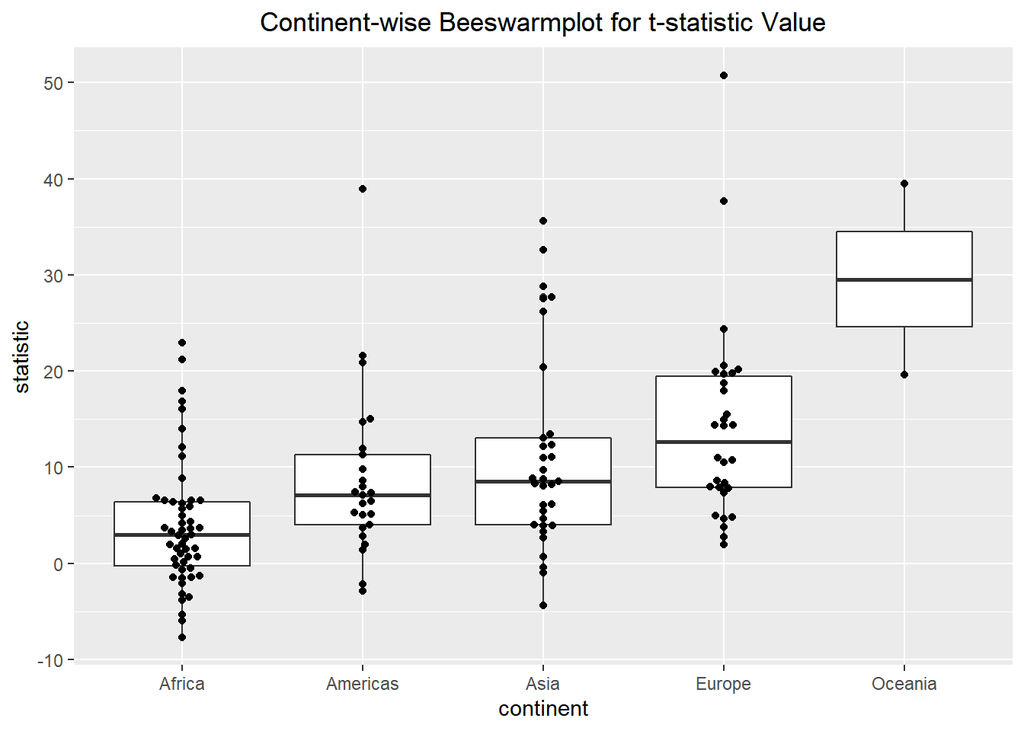

```r
gap_nested_lm_tidy %>%
  mutate(tidy = map(tidy, ~filter(., term == "year"))) %>%
  unnest(tidy) %>%
  ggplot(aes(continent, statistic)) +
  geom_boxplot() +
  geom_beeswarm() +
  labs(
    title = "Continent-wise Beeswarmplot for t-statistic Value"
  ) +
  theme(plot.title = element_text(hjust = 0.5))
```

## 4. Identify the countries that have estimated negative slopes and p-values less than 0.05. What is the interpretation of the linear model fit for these countries?

```r
negativeCountries <- gap_nested_lm_tidy %>%
  mutate(tidy = map(tidy, ~filter(., term == "year"))) %>%
  unnest(tidy) %>%
  filter(estimate < 0 & p.value < 0.05) %>%
  ungroup() %>%
  select(country, estimate, p.value)
negativeCountries
```

```
## # A tibble: 8 x 3
##   country                  estimate   p.value
##   <fct>                       <dbl>     <dbl>
## 1 Central African Republic -0.00461 0.0000171
## 2 Congo, Dem. Rep.         -0.0106  0.000139
## 3 Djibouti                 -0.00354 0.0103
## 4 Haiti                    -0.00277 0.0160
## 5 Kuwait                   -0.0105  0.00137
## 6 Madagascar               -0.00485 0.000337
## 7 Niger                    -0.00394 0.00591
## 8 Somalia                  -0.00316 0.00339
```

## 5. Plot the year-wise `log10(gdpPercap)` for the countries identified in step 4.

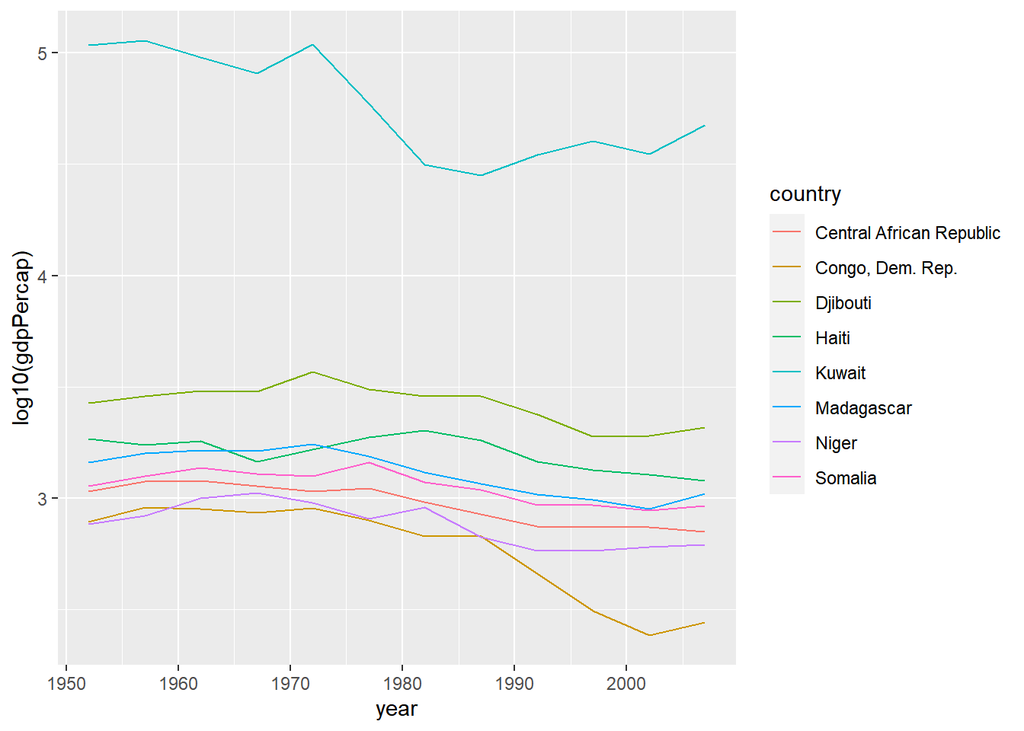

```r
gapminder %>%
  filter(country %in% negativeCountries$country) %>%
  group_by(country, continent) %>%
  ggplot(aes(x = year, y = log10(gdpPercap), color = country)) +
  geom_line()
```

# Problem 2

## In the lecture, we discussed fitting of a linear model of *mpg* versus *wt* from the mtcars data and demonstrated evaluation of its out-of-sample performance with a k-fold cross validation. Repeat this analysis for a non-linear model mpg ~ $\frac{k}{wt}+b$ , where k and b are model parameters and compare its performance with the linear model using an 8-fold cross validation.

### Set 8-fold cross validation

```r
mtcars_cv <- mtcars %>%
  crossv_kfold(k = 8)
mtcars_cv
```

```
## # A tibble: 8 x 3
##   train                test                .id
##   <named list>         <named list>        <chr>
## 1 <resample [28 x 11]> <resample [4 x 11]> 1
## 2 <resample [28 x 11]> <resample [4 x 11]> 2
## 3 <resample [28 x 11]> <resample [4 x 11]> 3
## 4 <resample [28 x 11]> <resample [4 x 11]> 4
## 5 <resample [28 x 11]> <resample [4 x 11]> 5
## 6 <resample [28 x 11]> <resample [4 x 11]> 6
## 7 <resample [28 x 11]> <resample [4 x 11]> 7
## 8 <resample [28 x 11]> <resample [4 x 11]> 8
```

### Define linear model mpg ~ wt

```r
mtcars_lm <- mtcars %>%
  lm(mpg ~ wt, .)
mtcars_lm
```

```
##
## Call:
## lm(formula = mpg ~ wt, data = .)
##
## Coefficients:
## (Intercept)           wt
##      37.285       -5.344
```

### Define non-linear model mpg ~ $\frac{k}{wt} + b$

```r
mtcars_nls <- mtcars %>%
  nls(mpg ~ k / wt + b, ., start = list(k = 1, b = 0))
mtcars_nls
```

```
## Nonlinear regression model
##   model: mpg ~ k/wt + b
##    data: .
##      k      b
## 45.829  4.386
##  residual sum-of-squares: 230.9
##
## Number of iterations to convergence: 1
## Achieved convergence tolerance: 2.877e-08
```

### Compute RSME for both model

```r
lm_rmse_mean <- mtcars_cv %>%
  mutate(lm = map(train, ~lm(mpg ~ wt, data = .))) %$%
  map2_dbl(lm, test, rmse) %>%
  mean()

nls_rmse_mean <- mtcars_cv %>%
  mutate(
    nls = map(train, ~nls(mpg ~ k/wt+b, data = .[[1]], start = list(k = 1, b = 0)))
  ) %$%
  map2_dbl(nls, test, rmse) %>%
  mean()

print(paste("Linear model RSME mean: ", lm_rmse_mean, sep = ''))
```

```
## [1] "Linear model RSME mean: 3.02643814260851"
```

```r
print(paste('Non-linear model RSME mean: ', nls_rmse_mean, sep = ''))
```

```
## [1] "Non-linear model RSME mean: 7.98014006113999"
```

Comparing the mean RSME of both models, we can see that linear model’s mean RSME is less than non-linear model’s one. This means that the linear model fits the performance of the linear model is better than non-linear model.

# Problem 3

## 1. Download the data frames “Dataset1-Media-Example-NODES.csv” and “Dataset1-Media-Example-EDGES.csv” from https://kateto.net/network-visualization, and create an igraph network object.

### Read nodes file and convert to tibble

```r
nodes <- read.csv(
  "Dataset1-Media-Example-NODES.csv",
  header = T,
  as.is = T
) %>%
  as_tibble()
nodes
```

```
## # A tibble: 17 x 5
##    id    media               media.type type.label audience.size
##    <chr> <chr>                    <int> <chr>              <int>
##  1 s01   NY Times                     1 Newspaper             20
##  2 s02   Washington Post              1 Newspaper             25
##  3 s03   Wall Street Journal          1 Newspaper             30
##  4 s04   USA Today                    1 Newspaper             32
##  5 s05   LA Times                     1 Newspaper             20
##  6 s06   New York Post                1 Newspaper             50
##  7 s07   CNN                          2 TV                    56
##  8 s08   MSNBC                        2 TV                    34
##  9 s09   FOX News                     2 TV                    60
## 10 s10   ABC                          2 TV                    23
## 11 s11   BBC                          2 TV                    34
## 12 s12   Yahoo News                   3 Online                33
## 13 s13   Google News                  3 Online                23
## 14 s14   Reuters.com                  3 Online                12
## 15 s15   NYTimes.com                  3 Online                24
## 16 s16   WashingtonPost.com           3 Online                28
## 17 s17   AOL.com                      3 Online                33
```

### Read edges files and convert to tibble

```r
links <- read.csv(
  "Dataset1-Media-Example-EDGES.csv",
  header = T,
  as.is = T
) %>%
  as_tibble()
links
```

```
## # A tibble: 49 x 4
##    from  to    type      weight
##    <chr> <chr> <chr>      <int>
##  1 s01   s02   hyperlink     22
##  2 s01   s03   hyperlink     22
##  3 s01   s04   hyperlink     21
##  4 s01   s15   mention       20
##  5 s02   s01   hyperlink     23
##  6 s02   s03   hyperlink     21
##  7 s02   s09   hyperlink      1
##  8 s02   s10   hyperlink      5
##  9 s03   s01   hyperlink     21
## 10 s03   s04   hyperlink     22
## # ... with 39 more rows
```

### Create the igraph object

```r
net_igraph <- graph_from_data_frame(d = links, vertices = nodes, directed = T)
net_igraph
```

```
## IGRAPH ad12ff1 DNW- 17 49 --
## + attr: name (v/c), media (v/c), media.type (v/n), type.label (v/c),
## | audience.size (v/n), type (e/c), weight (e/n)
## + edges from ad12ff1 (vertex names):
##  [1] s01->s02 s01->s03 s01->s04 s01->s15 s02->s01 s02->s03 s02->s09 s02->s10
##  [9] s03->s01 s03->s04 s03->s05 s03->s08 s03->s10 s03->s11 s03->s12 s04->s03
## [17] s04->s06 s04->s11 s04->s12 s04->s17 s05->s01 s05->s02 s05->s09 s05->s15
## [25] s06->s06 s06->s16 s06->s17 s07->s03 s07->s08 s07->s10 s07->s14 s08->s03
## [33] s08->s07 s08->s09 s09->s10 s10->s03 s12->s06 s12->s13 s12->s14 s13->s12
## [41] s13->s17 s14->s11 s14->s13 s15->s01 s15->s04 s15->s06 s16->s06 s16->s17
## [49] s17->s04
```

### Plot the graph

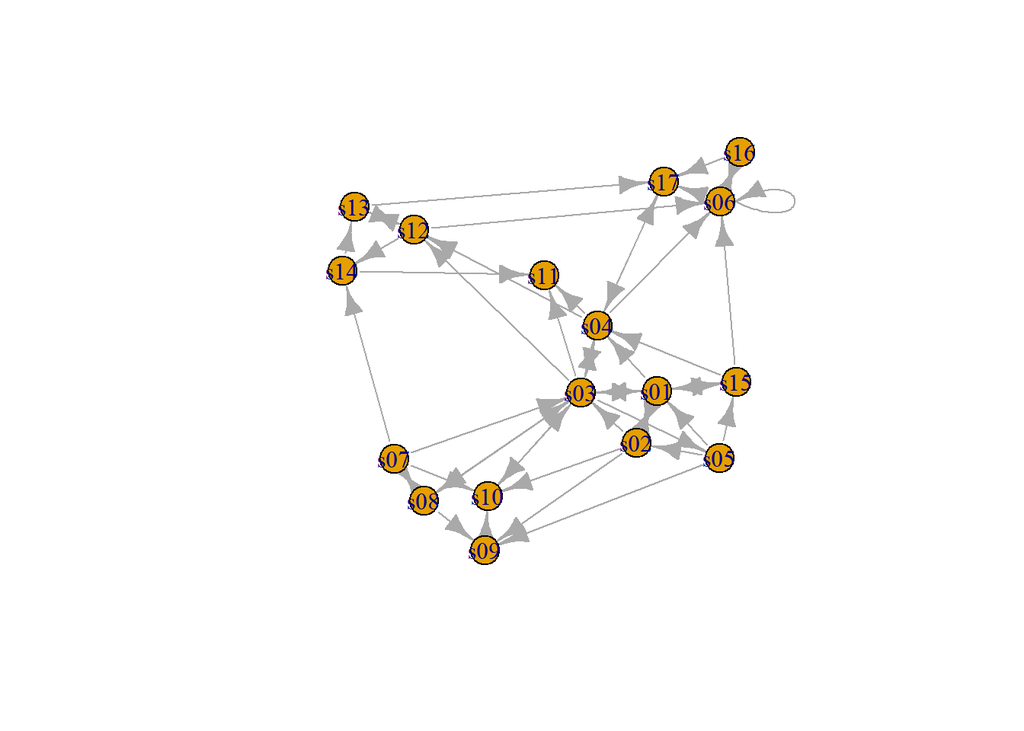

```r
plot(net_igraph)
```

## 2. Convert the igraph to a network object in the sna package

```r
net_network <- asNetwork(net_igraph)
net_network
```

```
##  Network attributes:
##   vertices = 17
##   directed = TRUE
##   hyper = FALSE
##   loops = TRUE
##   multiple = FALSE
##   bipartite = FALSE
##   total edges= 49
##     missing edges= 0
##     non-missing edges= 49
##
##  Vertex attribute names:
##     audience.size media media.type type.label vertex.names
##
##  Edge attribute names:
##     type weight
```

## 3. Plot the network using separate colors for the nodes based on the vertex attribute media.type and make the size of the nodes proportional to the vertex attribute audience.size. [Hint: Use network:;get.vertex.attribute]

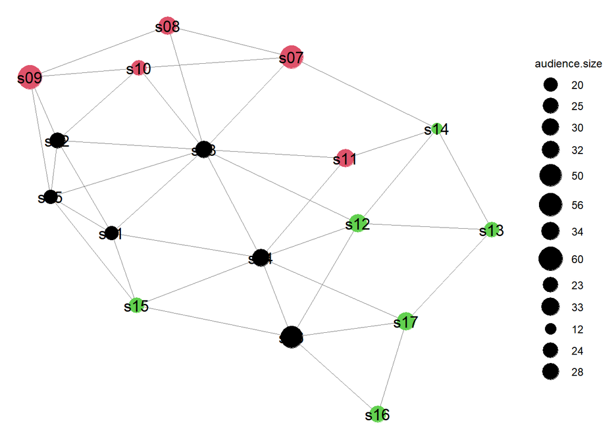

```r
net_network %>%
  ggnet2(size = "audience.size", color = "media.type", label = T)
```

## 4. Calculate the mean degree and density of the network using appropriate functions in the sna package.

### Mean degree

```r
net_network %>%
  degree(gmode = "graph") %>%
  mean()
```

```
## [1] 2.823529
```

### Density

```r
net_network %>%
  network.density()
```

```
## [1] 0.1695502
```

# Problem 4

## Scrape the country-wise population data from https://www.worldometers.info/world-population/population-by-country/. Plot the population density ($P/Km^2$) obtained from this table on a country-wise choropleth map. Make sure to

### 1. Clean the data to make it compatible with the country-wise world choropleth map

#### Scrape the data

```r
url <- "https://www.worldometers.info/world-population/population-by-country/"
country_population <- url %>%
  read_html() %>%
  html_nodes("table") %>%
  html_table(fill = TRUE) %>%
  .[[1]]
country_population
```

```
## # A tibble: 235 x 12
##      `#` `Country (or dependency)` `Population (2~` `Yearly Change` `Net Change`
##    <int> <chr>                     <chr>            <chr>           <chr>
##  1     1 China                     1,439,323,776    0.39 %          5,540,090
##  2     2 India                     1,380,004,385    0.99 %          13,586,631
##  3     3 United States             331,002,651      0.59 %          1,937,734
##  4     4 Indonesia                 273,523,615      1.07 %          2,898,047
##  5     5 Pakistan                  220,892,340      2.00 %          4,327,022
##  6     6 Brazil                    212,559,417      0.72 %          1,509,890
##  7     7 Nigeria                   206,139,589      2.58 %          5,175,990
##  8     8 Bangladesh                164,689,383      1.01 %          1,643,222
##  9     9 Russia                    145,934,462      0.04 %          62,206
## 10    10 Mexico                    128,932,753      1.06 %          1,357,224
## # ... with 225 more rows, and 7 more variables: `Density (P/Km2)` <chr>,
## #   `Land Area (Km2)` <chr>, `Migrants (net)` <chr>, `Fert. Rate` <chr>,
## #   `Med. Age` <chr>, `Urban Pop %` <chr>, `World Share` <chr>
```

#### Clean the data

```r
country_population <- country_population %>%
  rename(
    `Density (P/Km2)` = `Density (P/Km²)`,
    `Land Area (Km2)` = `Land Area (Km²)`
  ) %>%
  mutate(
    `Country (or dependency)` = tolower(`Country (or dependency)`),
    `Population (2020)` = as.integer(
      str_replace_all(.$`Population (2020)`, ",", "")
    ),
    `Yearly Change` = as.double(
      str_replace_all(.$`Yearly Change`, " %", "")
    ),
    `Net Change` = as.integer(
      str_replace_all(.$`Net Change`, ',', '')
    ),
    `Density (P/Km2)` = as.integer(
      str_replace_all(.$`Density (P/Km2)`, ',', '')
    ),
    `Land Area (Km2)` = as.integer(
      str_replace_all(.$`Land Area (Km2)`, ',', '')
    ),
    `Migrants (net)` = as.integer(
      str_replace_all(.$`Migrants (net)`, ',', '')
    ),
    `Fert. Rate` = as.double(`Fert. Rate`),
    `Med. Age` = as.integer(`Med. Age`),
    `Urban Pop %` = as.integer(
      str_replace_all(.$`Urban Pop %`, ' %', '')
    ),
    `World Share` = as.double(
      str_replace_all(.$`World Share`, ' %', '')
    )
  )

country_population
```

```
## # A tibble: 235 x 12
##      `#` `Country (or dependency)` `Population (2~` `Yearly Change` `Net Change`
##    <int> <chr>                                <int>           <dbl>        <int>
##  1     1 china                           1439323776            0.39      5540090
##  2     2 india                           1380004385            0.99     13586631
##  3     3 united states                    331002651            0.59      1937734
##  4     4 indonesia                        273523615            1.07      2898047
##  5     5 pakistan                         220892340            2         4327022
##  6     6 brazil                           212559417            0.72      1509890
##  7     7 nigeria                          206139589            2.58      5175990
##  8     8 bangladesh                       164689383            1.01      1643222
##  9     9 russia                           145934462            0.04        62206
## 10    10 mexico                           128932753            1.06      1357224
## # ... with 225 more rows, and 7 more variables: `Density (P/Km2)` <int>,
## #   `Land Area (Km2)` <int>, `Migrants (net)` <int>, `Fert. Rate` <dbl>,
## #   `Med. Age` <int>, `Urban Pop %` <int>, `World Share` <dbl>
```

### 2. Maximize the overlap between the two data frames (the one obtained from the scraped data and the choropleth country data frame), i.e., if a country appears in both data frames, possibly with different names, it must be plotted

### Maximize the overlap

```r
country_population <- country_population %>%
  mutate(
    `Country (or dependency)` = case_when(
      `Country (or dependency)` == "united states" ~ "united states of america",
      `Country (or dependency)` == 'serbia' ~ 'republic of serbia',
      `Country (or dependency)` == 'tanzania' ~ 'united republic of tanzania',
      `Country (or dependency)` == 'north macedonia' ~ 'macedonia',
      `Country (or dependency)` == 'bahamas' ~ 'the bahamas',
      `Country (or dependency)` == 'timor-leste' ~ 'east timor',
      str_detect(`Country (or dependency)`, "ivoire") ~ 'ivory coast',
      `Country (or dependency)` == 'dr congo' ~ 'democratic republic of the congo',
      `Country (or dependency)` == 'congo' ~ 'republic of congo',
      `Country (or dependency)` == 'czech republic (czechia)' ~ 'czech republic',
      `Country (or dependency)` == 'guinea-bissau' ~ 'guinea bissau',
      T ~ `Country (or dependency)`
    )
  )
```

```r
data(country.regions)
setdiff(
  country.regions$region,
  country_population$`Country (or dependency)`
) %>%
  as_tibble_col(column_name = "region")
```

```
## # A tibble: 5 x 1
##   region
##   <chr>
## 1 somaliland
## 2 swaziland
## 3 northern cyprus
## 4 antarctica
## 5 kosovo
```

```r
setdiff(
  country_population$`Country (or dependency)`,
  country.regions$region
) %>%
  as_tibble_col(column_name = "region")
```

```
## # A tibble: 69 x 1
##    region
##    <chr>
##  1 hong kong
##  2 singapore
##  3 state of palestine
##  4 puerto rico
##  5 bahrain
##  6 mauritius
##  7 eswatini
##  8 réunion
##  9 comoros
## 10 macao
## # ... with 59 more rows
```

### Plot the map

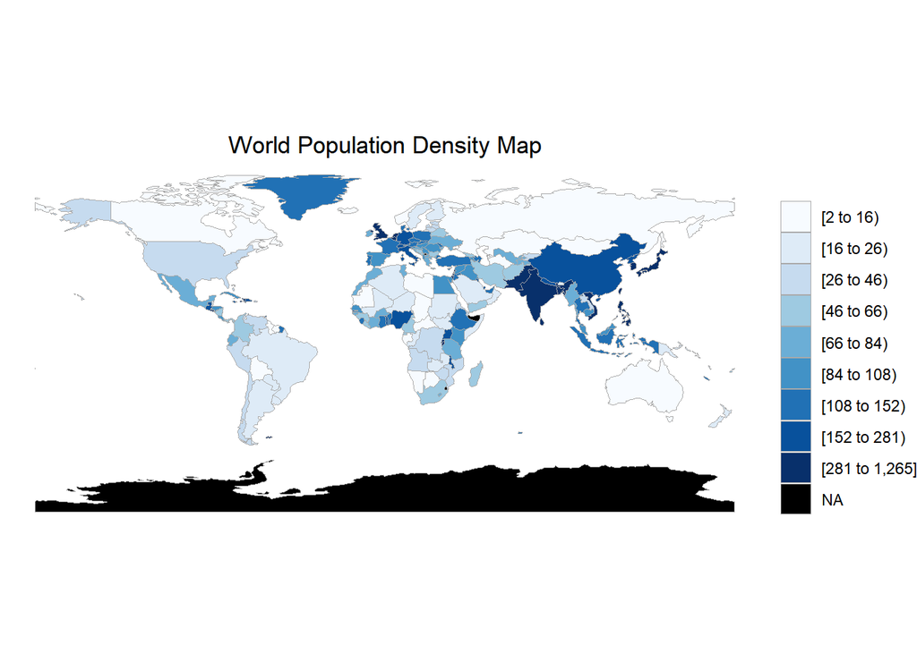

```r
country_population %>%
  mutate(region = `Country (or dependency)`, value = `Density (P/Km2)`) %>%
  country_choropleth(title = 'World Population Density Map', num_colors = 9) +
  theme(plot.title = element_text(hjust = 0.5))
```

# Problem 5

## Obtain 2016-2020 5-year aggregated ACS tract-wise data on NJ median household income and rental. Combine them into a single data frame.

### 1. Plot the tract-wise rental against the median household income and comment.

#### Set API key

```r
census_api_key("44ed2f559fc8ff1593dc792e28e54bd655f7f900", install = T, overwrite = T)
```

```
## Your original .Renviron will be backed up and stored in your R HOME directory if needed.
```

```
## Your API key has been stored in your .Renviron and can be accessed by Sys.getenv("CENSUS_API_KEY").
## To use now, restart R or run `readRenviron("~/.Renviron")`
```

```
## [1] "44ed2f559fc8ff1593dc792e28e54bd655f7f900"
```

#### Obtain the data and combine both income and rental to one tibble

```r
nj_median_household_income_and_rental <- get_acs(
  geography = "tract",
  variables = c(medincome = "B19013_001", medrental = "B25064_001"),
  state = "NJ",
  year = 2020,
  geometry = T
) %>%
  as_tibble() %>%
  pivot_wider(
    names_from = variable,
    values_from = c(estimate, moe)
  )
nj_median_household_income_and_rental
```

```
## # A tibble: 2,181 x 7
##    GEOID       NAME                   geometry estimate_medinc~ estimate_medren~
##    <chr>       <chr> <MULTIPOLYGON [arc_degre>            <dbl>            <dbl>
##  1 34021002200 Cens~ (((-74.74945 40.22568, -~            54860             1121
##  2 34021004404 Cens~ (((-74.50135 40.25484, -~           100282             1685
##  3 34021000600 Cens~ (((-74.74294 40.21703, -~            66029             1180
##  4 34021001200 Cens~ (((-74.81737 40.24094, -~            49659             1163
##  5 34025805700 Cens~ (((-74.01226 40.30434, -~            57823             1199
##  6 34025809703 Cens~ (((-74.29578 40.3226, -7~           130705             2262
##  7 34025807004 Cens~ (((-74.00926 40.23071, -~            52440             1210
##  8 34025810300 Cens~ (((-74.3717 40.29863, -7~            84091             1691
##  9 34025806504 Cens~ (((-74.05513 40.25025, -~            72267             1200
## 10 34025802500 Cens~ (((-74.23142 40.44554, -~            97232             1136
## # ... with 2,171 more rows, and 2 more variables: moe_medincome <dbl>,
## #   moe_medrental <dbl>
```

#### Import two library to help draw the graph

```r
library(biscale)
```

```r
library(cowplot)
```

#### Define the bi-class

```r
nj_median_household_income_and_rental <- nj_median_household_income_and_rental %>%
  bi_class(
    x = estimate_medincome,
    y = estimate_medrental,
    style = "quantile",
    dim = 3
  )
nj_median_household_income_and_rental
```

```
## # A tibble: 2,181 x 8
##    GEOID       NAME                   geometry estimate_medinc~ estimate_medren~
##    <chr>       <chr> <MULTIPOLYGON [arc_degre>            <dbl>            <dbl>
##  1 34021002200 Cens~ (((-74.74945 40.22568, -~            54860             1121
##  2 34021004404 Cens~ (((-74.50135 40.25484, -~           100282             1685
##  3 34021000600 Cens~ (((-74.74294 40.21703, -~            66029             1180
##  4 34021001200 Cens~ (((-74.81737 40.24094, -~            49659             1163
##  5 34025805700 Cens~ (((-74.01226 40.30434, -~            57823             1199
##  6 34025809703 Cens~ (((-74.29578 40.3226, -7~           130705             2262
##  7 34025807004 Cens~ (((-74.00926 40.23071, -~            52440             1210
##  8 34025810300 Cens~ (((-74.3717 40.29863, -7~            84091             1691
##  9 34025806504 Cens~ (((-74.05513 40.25025, -~            72267             1200
## 10 34025802500 Cens~ (((-74.23142 40.44554, -~            97232             1136
## # ... with 2,171 more rows, and 3 more variables: moe_medincome <dbl>,
## #   moe_medrental <dbl>, bi_class <chr>
```

#### Create the map

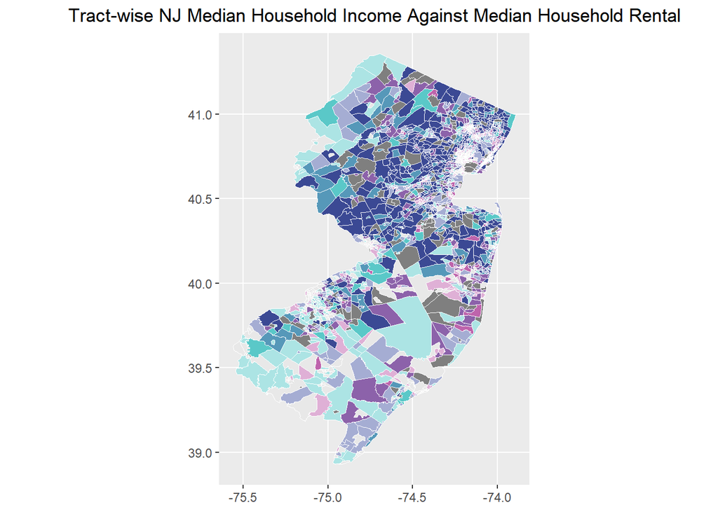

```r
map <- nj_median_household_income_and_rental %>%
  ggplot() +
  geom_sf(
    aes(fill = bi_class, geometry = geometry),
    color = "white",
    size = 0.1,
    show.legend = F
  ) +
  bi_scale_fill(pal = "DkBlue", dim = 3) +
  labs(
    x = NULL,
    y = NULL,
    title = "Tract-wise NJ Median Household Income Against Median Household Rental"
  ) +
  # theme_void() +
  theme(
    plot.title = element_text(hjust = 0.5)
  )
map
```

#### Create the legend

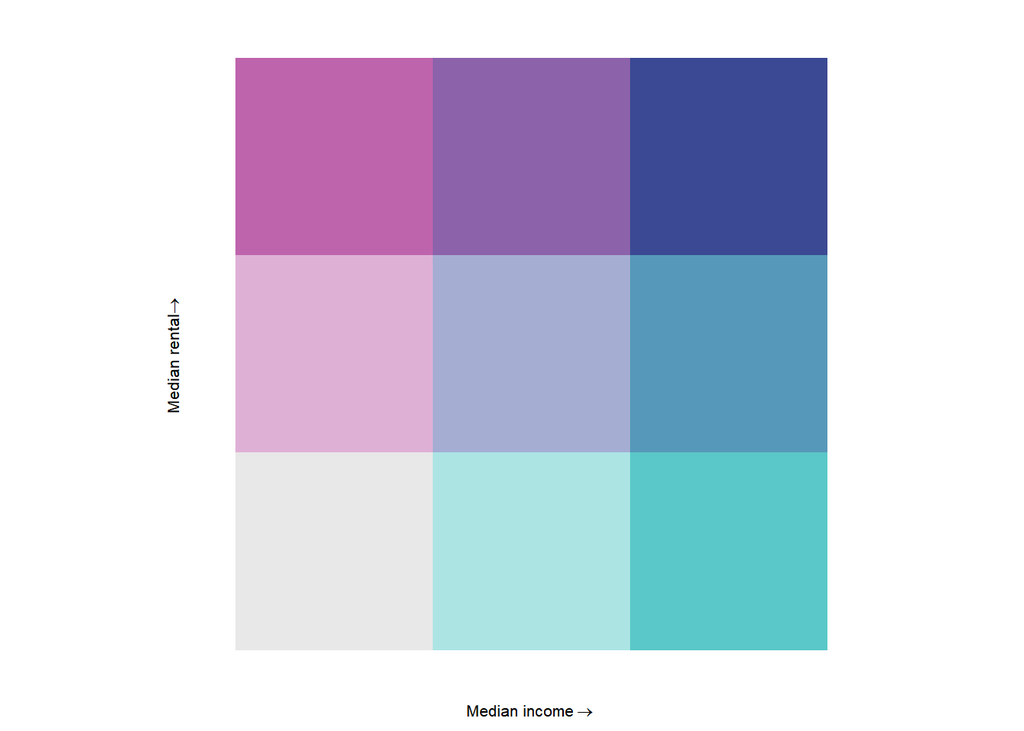

```r
legend <- bi_legend(
  pal = "DkBlue",
  dim = 3,
  xlab = "Median income",
  ylab = "Median rental",
  size = 8
)
legend
```

#### Combine the map with the legend to get the final plot

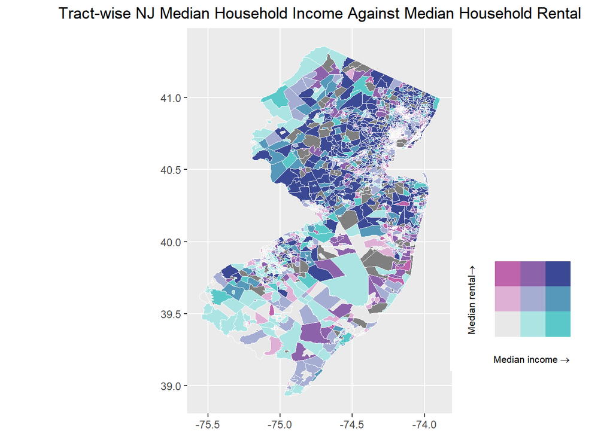

```r
ggdraw() +
  draw_plot(map, 0, 0, 1, 1) +
  draw_plot(legend, 0.7, 0.15, 0.3, 0.3)
```

Based on the above graph, most counties in the center Jersey and north Jersey are blue which means that people in these areas have a high income. Meanwhile, some counties in the south Jersey are in purple which means that people lived there may have a relatively high rental.

### 2. Fit a linear regression equation of rental against median household income and report the summary.

#### Fit a linear model to the data and show the summary of the model

```r
lm <- nj_median_household_income_and_rental %>%
  lm(estimate_medrental ~ estimate_medincome, .)
lm %>%
  tidy() %>%
  unnest()
```

```
## # A tibble: 2 x 5
##   term                estimate std.error statistic   p.value
##   <chr>                  <dbl>     <dbl>     <dbl>     <dbl>
## 1 (Intercept)        833.      20.0           41.8 3.54e-275
## 2 estimate_medincome   0.00756  0.000203      37.2 2.98e-231
```

```r
lm %>%
  glance
```

```
## # A tibble: 1 x 12
##   r.squared adj.r.squared sigma statistic   p.value    df  logLik    AIC    BIC
##       <dbl>         <dbl> <dbl>     <dbl>     <dbl> <dbl>   <dbl>  <dbl>  <dbl>
## 1     0.407         0.407  380.     1385. 2.98e-231     1 -14872. 29749. 29766.
## # ... with 3 more variables: deviance <dbl>, df.residual <int>, nobs <int>
```

#### Visualize the linear model

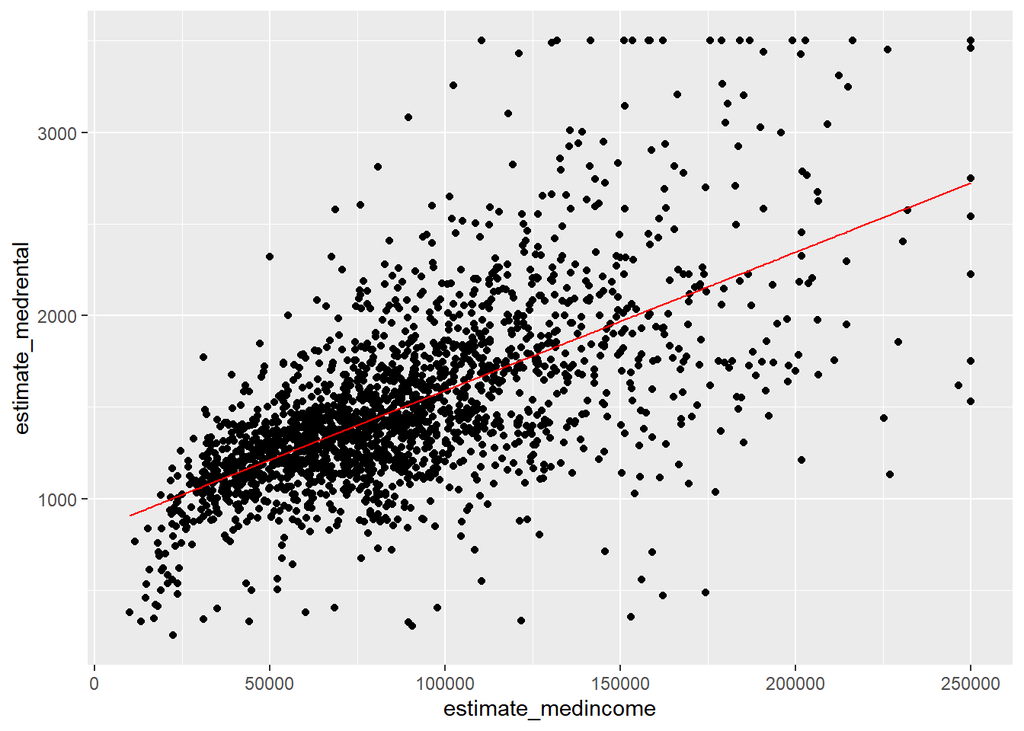

```r
nj_median_household_income_and_rental %>%
  add_predictions(lm) %>%
  ggplot() +
  geom_point(aes(estimate_medincome, estimate_medrental)) +
  geom_line(aes(estimate_medincome, pred), color = 'red')
```

### 3. Looking at the plot, suggest ways to improve the model fit. Fit the improved model and report the R2.

#### Fit a log10 model to the data and show the summary of the model

```r
nls <- nj_median_household_income_and_rental %>%
  lm(
    estimate_medrental ~ log(estimate_medincome, 10),
    .,
    # start = list(a = 1, b = 1, c = 1)
  )
nls %>%
  tidy %>%
  unnest()
```

```
## # A tibble: 2 x 5
##   term                        estimate std.error statistic   p.value
##   <chr>                          <dbl>     <dbl>     <dbl>     <dbl>
## 1 (Intercept)                   -5523.     197.      -28.0 6.54e-146
## 2 log(estimate_medincome, 10)    1434.      40.2      35.6 2.55e-216
```

```r
nls %>%
  glance
```

```
## # A tibble: 1 x 12
##   r.squared adj.r.squared sigma statistic   p.value    df  logLik    AIC    BIC
##       <dbl>         <dbl> <dbl>     <dbl>     <dbl> <dbl>   <dbl>  <dbl>  <dbl>
## 1     0.386         0.386  387.     1271. 2.55e-216     1 -14906. 29818. 29835.
## # ... with 3 more variables: deviance <dbl>, df.residual <int>, nobs <int>
```

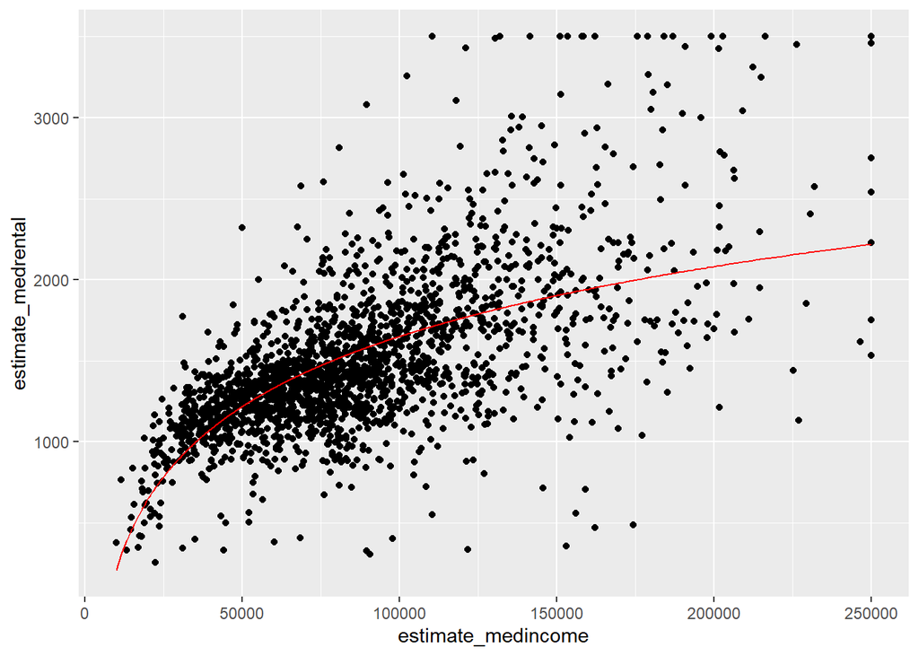

```r
nj_median_household_income_and_rental %>%
  add_predictions(nls) %>%
  ggplot() +
  geom_point(aes(estimate_medincome, estimate_medrental)) +
  geom_line(aes(estimate_medincome, pred), color = 'red')
```

### 4. Obtain the rental data for year=2020 (5-year aggregate from 2016-2020) and year=2015 (5-year aggregate from 2011-2015), and plot the percentage changes for each county in a column or bar diagram, in increasing or decreasing order of percentage increase.

#### Get the rental data from 2011-2015

```r
nj_median_rental_2011_2015 <- get_acs(
  geograph = "county",
  variables = c(medrental = "B25064_001"),
  state = "NJ",
  year = 2015,
  geometry = T
) %>%
  as_tibble() %>%
  rename(
    `2011-2015 Rental` = estimate
  )
nj_median_rental_2011_2015
```

```
## # A tibble: 21 x 6
##    GEOID NAME          variable `2011-2015 Ren~`   moe                  geometry
##    <chr> <chr>         <chr>               <dbl> <dbl> <MULTIPOLYGON [arc_degre>
##  1 34007 Camden Count~ medrent~              978    10 (((-75.13598 39.8932, -7~
##  2 34013 Essex County~ medrent~             1068     8 (((-74.37623 40.76275, -~
##  3 34019 Hunterdon Co~ medrent~             1328    36 (((-75.19511 40.57969, -~
##  4 34023 Middlesex Co~ medrent~             1299    13 (((-74.63 40.34341, -74.~
##  5 34041 Warren Count~ medrent~             1013    29 (((-75.20392 40.6915, -7~
##  6 34001 Atlantic Cou~ medrent~             1047    21 (((-74.98522 39.5148, -7~
##  7 34015 Gloucester C~ medrent~             1072    25 (((-75.4383 39.7844, -75~
##  8 34021 Mercer Count~ medrent~             1132    14 (((-74.94228 40.34089, -~
##  9 34029 Ocean County~ medrent~             1322    21 (((-74.55311 40.07913, -~
## 10 34031 Passaic Coun~ medrent~             1184    12 (((-74.50288 41.08592, -~
## # ... with 11 more rows
```

#### Get the rental data from 2016-2020

```r
nj_median_rental_2016_2020 <- get_acs(
  geograph = "county",
  variables = c(medrental = "B25064_001"),
  state = "NJ",
  year = 2020,
  geometry = T
) %>%
  as_tibble() %>%
  rename(
    `2016-2020 Rental` = estimate
  )
nj_median_rental_2016_2020
```

```
## # A tibble: 21 x 6
##    GEOID NAME          variable `2016-2020 Ren~`   moe                  geometry
##    <chr> <chr>         <chr>               <dbl> <dbl> <MULTIPOLYGON [arc_degre>
##  1 34041 Warren Count~ medrent~             1128    29 (((-75.20392 40.6915, -7~
##  2 34033 Salem County~ medrent~             1024    41 (((-75.41272 39.38437, -~
##  3 34005 Burlington C~ medrent~             1388    21 (((-75.05965 39.99215, -~
##  4 34021 Mercer Count~ medrent~             1311    23 (((-74.94295 40.34164, -~
##  5 34025 Monmouth Cou~ medrent~             1437    24 (((-74.61353 40.18267, -~
##  6 34017 Hudson Count~ medrent~             1450    14 (((-74.0422 40.69997, -7~
##  7 34031 Passaic Coun~ medrent~             1310    13 (((-74.50321 41.08587, -~
##  8 34027 Morris Count~ medrent~             1622    30 (((-74.88923 40.78883, -~
##  9 34013 Essex County~ medrent~             1211    11 (((-74.37623 40.76275, -~
## 10 34009 Cape May Cou~ medrent~             1176    45 (((-74.97191 38.94058, -~
## # ... with 11 more rows
```

#### Combine two data sets and compute the percentage change

```r
nj_median_rental <- inner_join(
  nj_median_rental_2011_2015,
  nj_median_rental_2016_2020,
  by = "GEOID"
) %>%
  mutate(
    `Percentage Change` = (`2016-2020 Rental` - `2011-2015 Rental`)/`2011-2015 Rental`,
    County = str_match(NAME.x, "(?<county>\\S*) County*")[, "county"]
  ) %>%
  select(
    County,
    `2011-2015 Rental`,
    `2016-2020 Rental`,
    `Percentage Change`
  )
nj_median_rental
```

```
## # A tibble: 21 x 4
##    County     `2011-2015 Rental` `2016-2020 Rental` `Percentage Change`
##    <chr>                   <dbl>              <dbl>               <dbl>
##  1 Camden                    978               1107              0.132
##  2 Essex                    1068               1211              0.134
##  3 Hunterdon                1328               1443              0.0866
##  4 Middlesex                1299               1495              0.151
##  5 Warren                   1013               1128              0.114
##  6 Atlantic                 1047               1129              0.0783
##  7 Gloucester               1072               1258              0.174
##  8 Mercer                   1132               1311              0.158
##  9 Ocean                    1322               1459              0.104
## 10 Passaic                  1184               1310              0.106
## # ... with 11 more rows
```

#### Plot the graph

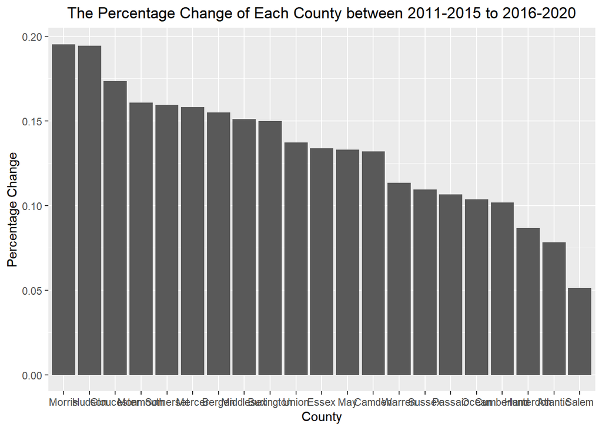

```r
nj_median_rental %>%
  ggplot(
    aes(
      x = reorder(County, -`Percentage Change`),
      y = `Percentage Change`
    )
  ) +
  geom_bar(stat = "identity") +
  labs(
    x = "County",
    y = "Percentage Change",
    title = "The Percentage Change of Each County between 2011-2015 to 2016-2020"
  ) +
  theme(plot.title = element_text(hjust = 0.5))
```